# College Football Preview 2022

[figure not shown]

```r
winProduction_newCoach <- teams_dataset %>%
  filter(new_headCoach == "Y") %>%
  ggplot(aes(x = returning_productionPercent, y = total_wins))
winProduction_newCoach + labs(x = "Returning Production % for 2022\n", y = "2021 Win Total\n", title = "New Head Coaches: Proven Talent", subtitle = "Dotted Line = National Median") + theme(plot.title = element_text(hjust = 0.5), plot.subtitle = element_text(hjust = 0.5)) + scale_x_continuous(breaks=c(40,48,56,64,72,80,85)) + scale_y_continuous(breaks=c(3,4,5,6,7,8,9,10,11)) + geom_point() + geom_vline(xintercept = median(teams_dataset$returning_productionPercent), linetype = 2) + geom_image(aes(image=team_logoLink), size=.075)
```

*Rush Offense vs Time of Possession, separated by Third Down Offense*

[figure not shown]

```r
timeOP_runO <- teams_dataset %>%
  mutate(g_name = ifelse(thirdDown_offense >= median(teams_dataset$thirdDown_offense), "Top Half of Third Down Offense", "Bottom Half of Third Down Offense")) %>%
  ggplot(aes(x = timeOf_posession, y = run_offense))
timeOP_runO + labs(x = "Time of Possession per Game\n", y = "Rushing Yards per Game\n", title = "Rushing Yards vs Time of Possession", subtitle = "TOP 60 Minutes total (30 = average) \n Rushing: Red Line = 25th Percentile, Green Line = 75th Percentile, Middle Line = Median") + theme(plot.title = element_text(hjust = 0.5), plot.subtitle = element_text(hjust = 0.5)) + scale_x_continuous(breaks=c(24,26,27,28,29,30,31,32,33,34,35)) + scale_y_continuous(breaks=c(63.2,84.3,105.4,126.5,147.6,168.7,189.8,208.8,227.8)) + geom_point() + geom_hline(yintercept = quantile(teams_dataset$run_offense, probs = 0.25), linetype = 2, colour = "red") + geom_hline(yintercept = quantile(teams_dataset$run_offense, probs = 0.75), linetype = 2, colour = "green") + geom_hline(yintercept = median(teams_dataset$run_offense), linetype = 2) + facet_grid(~ g_name) + geom_image(aes(image=team_logoLink), size=.065)
```

*Third Down Offense vs Time of Possession*

[figure not shown]

```r
timeOP_thirdO <- teams_dataset %>%
  mutate(g_name = ifelse(run_offense >= median(teams_dataset$run_offense), "Top Half of Rushing Offense", "Bottom Half of Rushing Offense")) %>%
  ggplot(aes(x = timeOf_posession, y = thirdDown_offense))
timeOP_thirdO + labs(x = "Time of Possession per Game\n", y = "Third Down Conversion Rate\n", title = "Third Down Offense vs Time of Possession", subtitle = "TOP 60 Minutes total (30 = average) \n 3rd Down: Red Line = 25th Percentile, Green Line = 75th Percentile, Middle Line = Median") + theme(plot.title = element_text(hjust = 0.5), plot.subtitle = element_text(hjust = 0.5)) + scale_x_continuous(breaks=c(24,26,27,28,29,30,31,32,33,34,35)) + scale_y_continuous(breaks=c(.228,.278,.328,.378,.428,.478,.528)) + geom_point() + geom_hline(yintercept = quantile(teams_dataset$thirdDown_offense, probs = 0.25), linetype = 2, colour = "red") + geom_hline(yintercept = quantile(teams_dataset$thirdDown_offense, probs = 0.75), linetype = 2, colour = "green") + geom_hline(yintercept = median(teams_dataset$thirdDown_offense), linetype = 2) + facet_grid(~ g_name) + geom_image(aes(image=team_logoLink), size=.075)
```

*Run Defense vs Time of Possession, separated by Third Down Defense*

[figure not shown]

```r
runD_timeOP <- teams_dataset %>%
  mutate(g_name = ifelse(thirdDown_defense <= median(teams_dataset$thirdDown_defense), "Top Half of Third Down Defense", "Bottom Half of Third Down Defense")) %>%
  ggplot(aes(x = timeOf_posession, y = run_defense))
runD_timeOP + labs(x = "Time of Possession per Game\n", y = "Rushing Yards Allowed per Game\n", title = "Rushing Defense vs Time of Possession", subtitle = "TOP 60 Minutes total (30 = average) \n Dotted Line = National Median") + theme(plot.title = element_text(hjust = 0.5), plot.subtitle = element_text(hjust = 0.5)) + scale_x_continuous(breaks=c(24,26,27,28,29,30,31,32,33,34,35)) + scale_y_reverse(breaks=c(65.2,88.6,112,135.4,158.8,182.2,205.6,229,250.4)) + geom_point() + geom_vline(xintercept = 30, linetype = 2)  + geom_hline(yintercept = median(teams_dataset$run_defense), linetype = 2) + facet_grid(~ g_name) + geom_image(aes(image=team_logoLink), size=.065)
```

*Third Down Defense vs Time of Possession, separated by Run Defense*

[figure not shown]

```r
timeOP_thirdD <- teams_dataset %>%
  mutate(g_name = ifelse(run_defense <= median(teams_dataset$run_defense), "Top Half of Teams in Run Defense", "Bottom Half of Teams in Run Defense")) %>%
  ggplot(aes(x = timeOf_posession, y = thirdDown_defense))
timeOP_thirdD + labs(x = "Time of Possession per Game\n", y = "Third Down Defense Conversion Rate Allowed\n", title = "Third Down Defense vs Time of Possession", subtitle = "TOP 60 Minutes total (30 = average) \n Dotted Line = National Median") + theme(plot.title = element_text(hjust = 0.5), plot.subtitle = element_text(hjust = 0.5)) + scale_x_continuous(breaks=c(24,26,27,28,29,30,31,32,33,34,35)) + scale_y_reverse(breaks=c(.257,.288,.319,.350,.381,.412,.443,.474,.504,.547)) + geom_point() + geom_vline(xintercept = 30, linetype = 2)  + geom_hline(yintercept = median(teams_dataset$thirdDown_defense), linetype = 2) + facet_grid(~ g_name) + geom_image(aes(image=team_logoLink), size=.075)
```

*bar graph with the average recruiting class rank average 2021/2022 for each conference*

```r
conference_recruit <- teams_dataset %>%
  filter(team_conference != "Independent") %>%
  group_by(team_conference) %>%
  select(team_conference, recruitingRankAvg_lastTwoYr) %>%
  summarise("recruit_avg" = mean(recruitingRankAvg_lastTwoYr, na.rm = TRUE), "Median Recruiting Average" = median(recruitingRankAvg_lastTwoYr, na.rm = TRUE), "Lowest Rank" = max(recruitingRankAvg_lastTwoYr, na.rm = TRUE), "Highest Rank" = min(recruitingRankAvg_lastTwoYr, na.rm = TRUE))

conference_recruit
```

| team_conference | recruit_avg | Median Recruiting Average | Lowest Rank | Highest Rank |
| --- | --- | --- | --- | --- |
| AAC | 79.77273 | 77.00 | 120.0 | 43.5 |
| ACC | 43.42857 | 49.75 | 77.5 | 7.5 |
| Big Ten | 32.78571 | 32.50 | 59.0 | 3.0 |
| Big12 | 43.15000 | 44.00 | 89.5 | 9.0 |
| Pac12 | 49.33333 | 47.75 | 82.5 | 9.5 |
| SEC | 20.25000 | 20.50 | 51.5 | 1.5 |

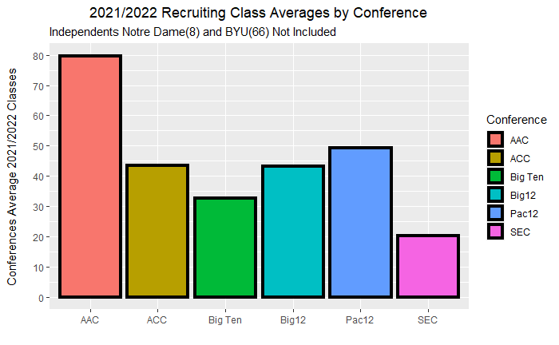

```r
conference_recruitPlot <- ggplot(data = conference_recruit, (aes(x = team_conference, y = recruit_avg, fill = team_conference)))
conference_recruitPlot + geom_bar(position = "dodge", stat = "summary", fun = "mean", color = "black", size = 1.5, bindwidth = 1.5) + labs(y = "Conferences Average 2021/2022 Classes\n", x = "", title = "2021/2022 Recruiting Class Averages by Conference", subtitle = "Independents Notre Dame(8) and BYU(66) Not Included", fill = "Conference") + theme(plot.title = element_text(hjust = 0.5)) + scale_y_continuous(breaks=c(0,10,20,30,40,50,60,70,80))
```

*Histogram to show the distribution of values for Turnover Margin*

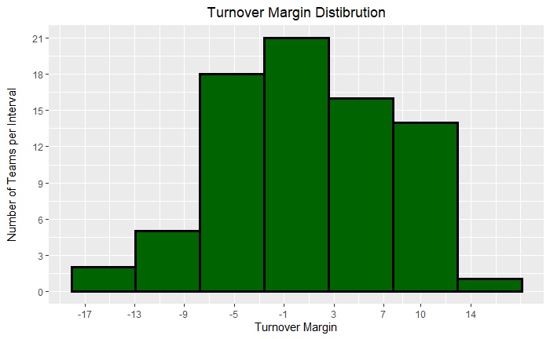

```r
histo_turnoverMarg <- ggplot(data = teams_dataset, aes(x = turnover_margin))
histo_turnoverMarg + geom_histogram(color = "black", fill = "dark green", size = 1.2, bindwidth = 1, bins = 7) + labs(x = "Turnover Margin", y = "Number of Teams per Interval\n", title = "Turnover Margin Distibrution") + theme(plot.title = element_text(hjust = 0.5)) + scale_x_continuous(breaks=c(-17,-13,-9,-5,-1,3,7,10,14)) + scale_y_continuous(breaks=c(0,3,6,9,12,15,18,21))
```

*Pie Graph showing passing offense vs rushing offense for a single team to show their balance*

```r
count.data <- data.frame(
  category = c("Pass Offense", "Rush Offense"),
  n = c(288.4,126.2),
  perc = c(70,30)
)
count.data
```

| category | n | perc |
| --- | --- | --- |
| Pass Offense | 288.4 | 70 |
| Rush Offense | 126.2 | 30 |

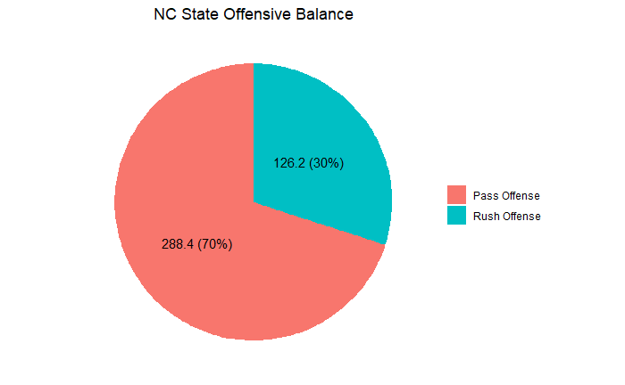

```r
ggplot(data = count.data, aes(x = "", y = perc, fill = category)) + geom_bar(stat = "identity", width = 1) + coord_polar("y", start = 0) + geom_text(aes(label = paste0(n, " (", perc, "%)")), position = position_stack(vjust=0.5)) + labs(x = NULL, y = NULL, fill = NULL, title = "NC State Offensive Balance") + theme_classic() + theme(axis.line = element_blank(), axis.text = element_blank(), axis.ticks = element_blank(), plot.title = element_text(hjust = 0.5))
```

*Mississippi State*

```r
balance_data <- data.frame(
  category = c("Pass Offense", "Rush Offense"),
  n = c(378.3,63.2),
  perc = c(86,14)
)
balance_data
```

| category | n | perc |
| --- | --- | --- |
| Pass Offense | 378.3 | 86 |
| Rush Offense | 63.2 | 14 |

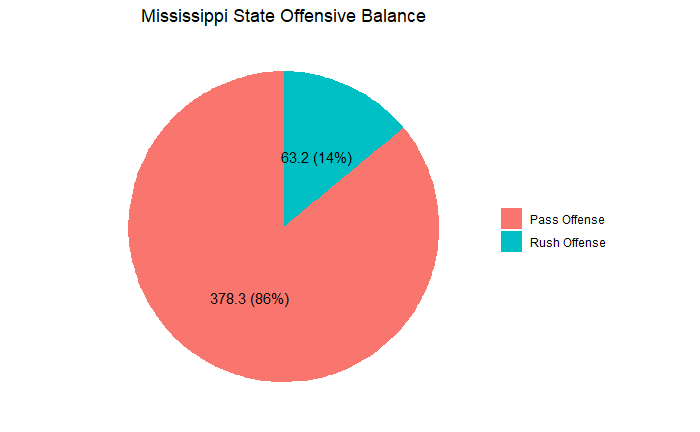

```r
ggplot(data = balance_data, aes(x = "", y = perc, fill = category)) + geom_bar(stat = "identity", width = 1) + coord_polar("y", start = 0) + geom_text(aes(label = paste0(n, " (", perc, "%)")), position = position_stack(vjust=0.5)) + labs(x = NULL, y = NULL, fill = NULL, title = "Mississippi State Offensive Balance") + theme_classic() + theme(axis.line = element_blank(), axis.text = element_blank(), axis.ticks = element_blank(), plot.title = element_text(hjust = 0.5))
```

*Navy Offense*

```r
balance_data2 <- data.frame(
  category = c("Pass Offense", "Rush Offense"),
  n = c(56.8,226),
  perc = c(20,80)
)
balance_data2
```

| category | n | perc |
| --- | --- | --- |
| Pass Offense | 56.8 | 20 |
| Rush Offense | 226.0 | 80 |

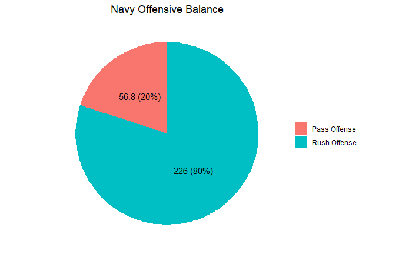

```r
ggplot(data = balance_data2, aes(x = "", y = perc, fill = category)) + geom_bar(stat = "identity", width = 1) + coord_polar("y", start = 0) + geom_text(aes(label = paste0(n, " (", perc, "%)")), position = position_stack(vjust=0.5)) + labs(x = NULL, y = NULL, fill = NULL, title = "Navy Offensive Balance") + theme_classic() + theme(axis.line = element_blank(), axis.text = element_blank(), axis.ticks = element_blank(), plot.title = element_text(hjust = 0.5))
```